# 01-QC metrics summary

Marc Elosua-Bayes

9/28/2020

## Introduction

BCLLATLAS_32 is a project within the context of the BCLL@las which aims to generate a B cell atlas, its lineages, trajectories and spatial localization on the tissue. The objective of this notebook is to perform a basic quality control (QC) analysis of the mapping performed with [spaceranger 1.1.0](https://support.10xgenomics.com/spatial-gene-expression/software/pipelines/latest/using/count).

Reference script from Massonix: https://github.com/massonix/tonsil_atlas/blob/master/2-DOWNSTREAM_PROCESSING/2-QC/01-qc_cellranger_mapping.Rmd

## Load packages

```r
library(ggpubr)
library(ggrepel)
library(DT)
library(dplyr)
library(readr)
library(ggplot2)
library(stringr)
library(gt)
```

## Parameters

Loading necessary paths and parameters

```r
source(here::here("misc/paths.R"))

"{qc}/{plt_dir}" %>%
  glue::glue() %>%
  here::here() %>%
  dir.create(path = .,
             showWarnings = FALSE,
             recursive = TRUE)

"{qc}/{robj_dir}" %>%
  glue::glue() %>%
  here::here() %>%
  dir.create(path = .,
             showWarnings = FALSE,
             recursive = TRUE)
```

## Load data

We have 8 different datasets, 1 for each capture area from 2 Visium slides.

```r
qcmetric_df <- lapply(id_sp_df$gem_id, function(id) {
  tmp_df <- "{spaceranger}/{id}/outs/metrics_summary.csv" %>%
    glue::glue() %>%
    here::here() %>%
    readr::read_csv(file = .) %>%
    dplyr::mutate(sample_id = id_sp_df[id_sp_df$gem_id == id, ] %>% dplyr::pull(donor_id)) %>%
    dplyr::rename(gem_id = `Sample ID`) %>%
    dplyr::select(sample_id, gem_id, dplyr::everything())

  return(tmp_df)
}) %>% dplyr::bind_rows()

colnames(qcmetric_df) <- stringr::str_replace_all(
  string = colnames(qcmetric_df),
  pattern = " ",
  replacement = "_")

DT::datatable(qcmetric_df)
```

|  | sample_id | gem_id | Number_of_Spots_Under_Tissue | Median_Genes_per_Spot | Number_of_Reads | Valid_Barcodes | Valid_UMIs | Mean_Reads_per_Spot | Sequencing_Saturation | Q30_Bases_in_Barcode | Q30_Bases_in_RNA_Read | Q30_Bases_in_UMI | Reads_Mapped_to_Genome | Reads_Mapped_Confidently_to_Genome | Reads_Mapped_Confidently_to_Intergenic_Regions | Reads_Mapped_Confidently_to_Intronic_Regions | Reads_Mapped_Confidently_to_Exonic_Regions | Reads_Mapped_Confidently_to_Transcriptome | Reads_Mapped_Antisense_to_Gene | Fraction_Reads_in_Spots_Under_Tissue | Total_Genes_Detected | Median_UMI_Counts_per_Spot | Fraction_of_Spots_Under_Tissue |
| --- | --- | --- | --- | --- | --- | --- | --- | --- | --- | --- | --- | --- | --- | --- | --- | --- | --- | --- | --- | --- | --- | --- | --- |
| 1 | BCLL-2-T | tarwe1_xott6q | 2194 | 1930.5 | 268773782 | 0.974945647786435 | 0.999046458333499 | 122504.002734731 | 0.879540472170823 | 0.972387556815272 | 0.953575402961737 | 0.971389146671518 | 0.931354647530316 | 0.871155952257278 | 0.0215643912768248 | 0.0208303092598518 | 0.828761251720601 | 0.814501568460275 | 0.00491509249960995 | 0.728708848053524 | 22755 | 5385 | 0.439503205128205 |
| 2 | BCLL-8-T | c28w2r_7jne4i | 2147 | 1758 | 297419103 | 0.975322795590571 | 0.999278620647309 | 138527.761061947 | 0.899625300025569 | 0.974217503351902 | 0.950150439066611 | 0.972868355671426 | 0.952912264683953 | 0.915470567470577 | 0.0164328382094542 | 0.0192526469962489 | 0.879785082264874 | 0.860204840305769 | 0.00818457515151608 | 0.773770173810417 | 22332 | 3774 | 0.430088141025641 |
| 3 | BCLL-10-T | esvq52_nluss5 | 3079 | 3451 | 265835692 | 0.971331280075062 | 0.9983305552514 | 86338.3215329652 | 0.781510980329348 | 0.974446906916989 | 0.954600450217671 | 0.974619186844305 | 0.958746040016327 | 0.924073558941062 | 0.0116513285958606 | 0.0152407864027529 | 0.897181443942448 | 0.875638881478714 | 0.00930384096052836 | 0.790973819724761 | 23155 | 11201 | 0.616786858974359 |
| 4 | BCLL-12-T | p7hv1g_tjgmyj | 3089 | 2943 | 296562214 | 0.9726885941039 | 0.998558123793883 | 96005.8964066041 | 0.818795755441397 | 0.973733277407937 | 0.954078523899668 | 0.972687823881748 | 0.94277859349944 | 0.898722077250206 | 0.0133687193203919 | 0.0139515852144265 | 0.871401772715387 | 0.850667364521361 | 0.00821744269821239 | 0.632429845553191 | 22913 | 7853 | 0.618790064102564 |
| 5 | BCLL_13T | gcyl7c_cec61b | 913 | 2665 | 160306662 | 0.97159489229462 | 0.999942192046891 | 175582.324205915 | 0.890918668726756 | 0.977657619806553 | 0.965318593846213 | 0.978394810358328 | 0.987042035720262 | 0.94227510644567 | 0.011965653679446 | 0.00965633605420591 | 0.920653116712018 | 0.900799306768673 | 0.00830520069091078 | 0.713901183038083 | 20036 | 10920 | 0.182892628205128 |
| 6 | BCLL_14T | zrt7gl_lhyyar | 1345 | 2193 | 187831926 | 0.975659846026389 | 0.999949987202921 | 139651.989591078 | 0.868657538691964 | 0.972779766823086 | 0.968943545081628 | 0.975527873431556 | 0.988120581801413 | 0.960280724587789 | 0.015728896907547 | 0.00950935785006006 | 0.935042469830182 | 0.918968077876175 | 0.00497096004861282 | 0.644038212496345 | 20806 | 8490 | 0.26943108974359 |
| 7 | BCLL_9T | qvwc8t_2vsr67 | 2170 | 2874 | 157916024 | 0.976113424689568 | 0.999934167542111 | 72772.3612903226 | 0.748995078088943 | 0.977244063238578 | 0.962984281884754 | 0.978226628540242 | 0.966559676046555 | 0.933063879571841 | 0.0113409516946805 | 0.0138658379595474 | 0.907857089917613 | 0.892528214869442 | 0.00420806567419656 | 0.774824946229287 | 22052 | 9826 | 0.434695512820513 |
| 8 | BCLL_11T | exvyh1_66caqq | 2012 | 3174.5 | 218793436 | 0.975676304109964 | 0.999934824370142 | 108744.252485089 | 0.823251297700231 | 0.977987085706504 | 0.963200425356748 | 0.97884315147675 | 0.970820468306919 | 0.941361065329218 | 0.0113915346162396 | 0.0135504979226159 | 0.916419032790362 | 0.900695837145681 | 0.00417387293099597 | 0.774234526824304 | 21646 | 11795 | 0.403044871794872 |

## Gene Expression QC

```r
top_metrics_gex <- qcmetric_df[, c("gem_id",
                                   "sample_id",
                                   "Number_of_Reads",
                                   "Number_of_Spots_Under_Tissue",
                                   "Fraction_Reads_in_Spots_Under_Tissue",
                                   "Mean_Reads_per_Spot",
                                   "Reads_Mapped_Confidently_to_Exonic_Regions",
                                   "Median_Genes_per_Spot")]
top_metrics_gex %>%
  gt::gt() %>%
  gt::fmt_percent(columns = c("Fraction_Reads_in_Spots_Under_Tissue", "Reads_Mapped_Confidently_to_Exonic_Regions"),
              scale_values = FALSE, decimals = 1) %>%
  gt::fmt_number(columns = "Number_of_Reads", scale_by = 1 / 1E6, pattern = "{x}M") %>%
  gt::tab_header(
    title = gt::md("**GEX QC metrics**"),
    subtitle = ("spaceranger v1.1.0")
  ) %>%
  gt::cols_label(
    gem_id = gt::md("**GEM ID**"),
    sample_id = gt::md("**SAMPLE ID**"),
    Number_of_Reads = gt::md("**Number of Reads**"),
    Number_of_Spots_Under_Tissue = gt::md("**Number of_Spots Under Tissue**"),
    Fraction_Reads_in_Spots_Under_Tissue = gt::md("**Fraction Reads in Spots Under Tissue**"),
    Mean_Reads_per_Spot = gt::md("**Mean Reads per Spot**"),
    Reads_Mapped_Confidently_to_Exonic_Regions = gt::md("**Fraction of Reads Mapped to Exonic Reads**"),
    Median_Genes_per_Spot = gt::md("**Median Genes per Spot**")
  )
```

**GEX QC metrics**

spaceranger v1.1.0

| **GEM ID** | **SAMPLE ID** | **Number of Reads** | **Number of_Spots Under Tissue** | **Fraction Reads in Spots Under Tissue** | **Mean Reads per Spot** | **Fraction of Reads Mapped to Exonic Reads** | **Median Genes per Spot** |
| --- | --- | --- | --- | --- | --- | --- | --- |
| tarwe1_xott6q | BCLL-2-T | 268.77M | 2194 | 0.7% | 122504.00 | 0.8% | 1930.5 |
| c28w2r_7jne4i | BCLL-8-T | 297.42M | 2147 | 0.8% | 138527.76 | 0.9% | 1758.0 |
| esvq52_nluss5 | BCLL-10-T | 265.84M | 3079 | 0.8% | 86338.32 | 0.9% | 3451.0 |
| p7hv1g_tjgmyj | BCLL-12-T | 296.56M | 3089 | 0.6% | 96005.90 | 0.9% | 2943.0 |
| gcyl7c_cec61b | BCLL_13T | 160.31M | 913 | 0.7% | 175582.32 | 0.9% | 2665.0 |
| zrt7gl_lhyyar | BCLL_14T | 187.83M | 1345 | 0.6% | 139651.99 | 0.9% | 2193.0 |
| qvwc8t_2vsr67 | BCLL_9T | 157.92M | 2170 | 0.8% | 72772.36 | 0.9% | 2874.0 |
| exvyh1_66caqq | BCLL_11T | 218.79M | 2012 | 0.8% | 108744.25 | 0.9% | 3174.5 |

## Sequencing QC

First, we will assess the quality of the sequenced libraries before the mapping step. To so do, we will use the “Q30” variables in our dataset, as these report the fraction of the bases with a Q-score >30 for different sequences (barcodes, reads and UMIs). Q-score is calculated in the following way:
$$Q = -10\log10(p)$$
where *p* is the probability of the base being wrongly called. Thus, bases with a high Q-score are reliable.

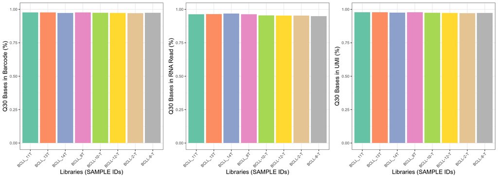

```r
qc_seq_vars <- c("Q30_Bases_in_Barcode",
                 "Q30_Bases_in_RNA_Read",
                 "Q30_Bases_in_UMI")
gg_qc_seq <- purrr::map(qc_seq_vars, function(var) {
  ggplot2::ggplot(qcmetric_df, ggplot2::aes_string(x = "sample_id", y = var, fill = "sample_id")) +
    ggplot2::geom_col() +
    ggplot2::theme_bw() +
    ggplot2::scale_fill_brewer(palette = "Set2") +
    ggplot2::ylim(0, 1) +
    ggplot2::labs(x = "Libraries (SAMPLE IDs)",
         y = str_c(str_replace_all(var, "_", " "), " (%)")) +
    ggplot2::theme(
      axis.title = ggplot2::element_text(size = 12),
      axis.text = ggplot2::element_text(size = 8),
      axis.text.x = ggplot2::element_text(hjust = 1, angle = 45),
      strip.placement = "outside",
      strip.background = ggplot2::element_rect(colour = NA),
      legend.position = "none")
})
cowplot::plot_grid(plotlist = gg_qc_seq,
                   nrow = 1,
                   ncol = 3,
                   align = "hv",
                   axis = "trbl")
```

## Mapping QC

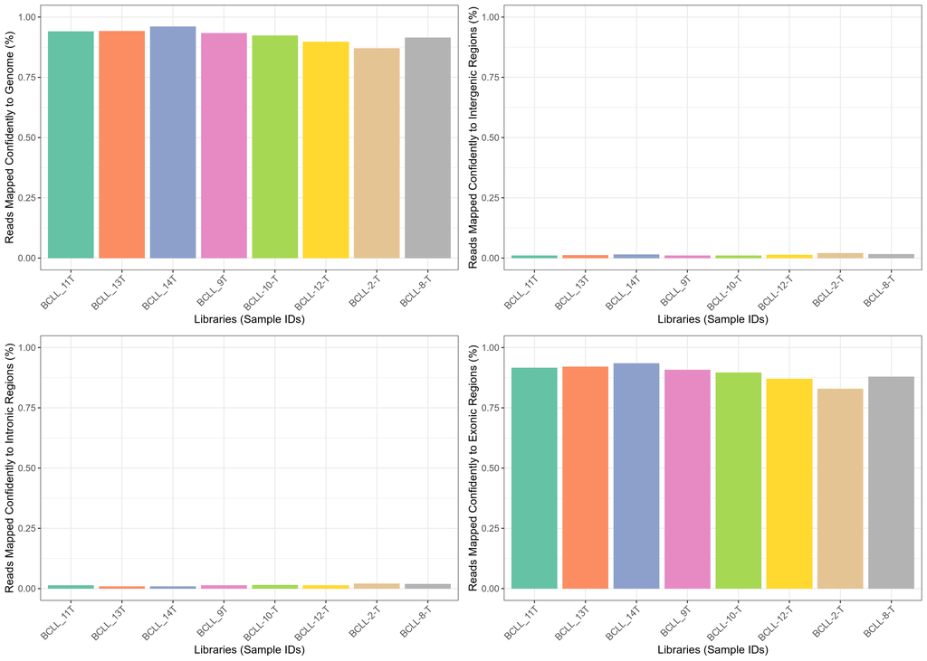

```r
qc_map_vars <- c("Reads_Mapped_Confidently_to_Genome",
                 "Reads_Mapped_Confidently_to_Intergenic_Regions",
                 "Reads_Mapped_Confidently_to_Intronic_Regions",
                 "Reads_Mapped_Confidently_to_Exonic_Regions")

gg_qc_map <- purrr::map(qc_map_vars, function(var) {
  ggplot2::ggplot(qcmetric_df, ggplot2::aes_string(x = "sample_id", y = var, fill = "sample_id")) +
    ggplot2::geom_col() +
    ggplot2::theme_bw() +
    ggplot2::scale_fill_brewer(palette = "Set2") +
    ggplot2::ylim(0, 1) +
    ggplot2::labs(x = "Libraries (Sample IDs)",
         y = str_c(str_replace_all(var, "_", " "), " (%)")) +
    ggplot2::theme(
      axis.title = ggplot2::element_text(size = 12),
          axis.text = ggplot2::element_text(size = 10),
          axis.text.x = ggplot2::element_text(hjust = 1, angle = 45),
          strip.placement = "outside",
          strip.background = ggplot2::element_rect(colour = NA),
          legend.position = "none")
})
cowplot::plot_grid(plotlist = gg_qc_map,
                   nrow = 2,
                   ncol = 2,
                   align = "hv",
                   axis = "trbl")
```

## Sequencing saturation and depth

After assessing mapped reads, it is important to test which is the sequencing saturation and depth for each library. The sequencing saturation is dependent on the library complexity and sequencing depth. The library complexity is the total number of different transcripts present in the library and it varies between the cell types/tissues, whereas the sequencing depth is the number of paired reads per cell. For this reason, we will plot the number of detected genes as a function of depth (sequenced reads). As sequencing depth increases, more genes are detected, but this function reaches a plateau, whereby more sequenced reads does not result in more detected genes; therefore, at this point we assure we sequenced until saturation. More specifically, the sequencing saturation the fraction of confidently mapped, valid cell-barcode, valid UMI reads that had a non-unique (cell-barcode, UMI, gene).

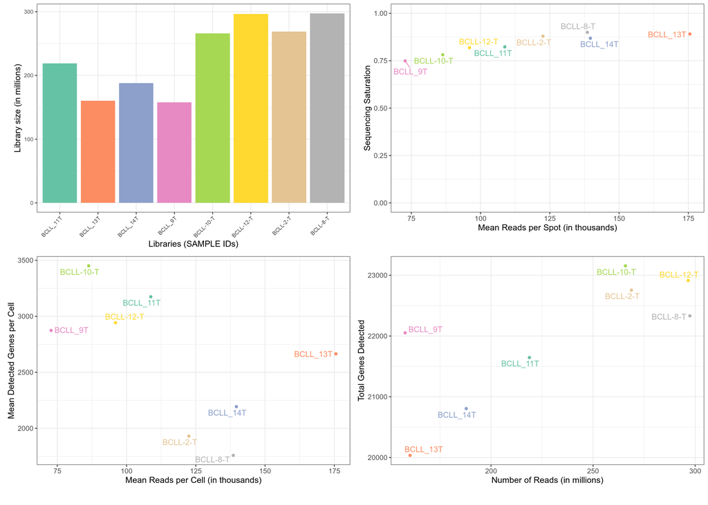

```r
gg_lib_size <- qcmetric_df %>%
  dplyr::mutate(Number_of_Reads_mil = Number_of_Reads / 1000000) %>%
  ggplot2::ggplot(ggplot2::aes(x = sample_id, y = Number_of_Reads_mil, fill = sample_id)) +
  ggplot2::geom_bar(stat = "identity") +
  ggplot2::theme_bw() +
  ggplot2::scale_fill_brewer(palette = "Set2") +
  ggplot2::labs(x = "Libraries (SAMPLE IDs)", y = "Library size (in millions)") +
  ggplot2::theme(
    axis.title = ggplot2::element_text(size = 12),
    axis.text = ggplot2::element_text(size = 8),
    axis.text.x = ggplot2::element_text(hjust = 1, angle = 45),
    strip.placement = "outside",
    strip.background = ggplot2::element_rect(colour = NA),
    legend.position = "none")

gg_qc_seq_sat <- qcmetric_df %>%
  dplyr::mutate(Sequencing_Saturation_perc = Sequencing_Saturation,
         Mean_Reads_per_Spot_tho = Mean_Reads_per_Spot / 1000) %>%
  ggplot2::ggplot(ggplot2::aes(x = Mean_Reads_per_Spot_tho,
             y = Sequencing_Saturation_perc, color = sample_id)) +
  ggplot2::geom_point() +
  ggplot2::theme_bw() +
  ggplot2::scale_color_brewer(palette = "Set2") +
  ggplot2::ylim(0, 1) +
  ggrepel::geom_text_repel(ggplot2::aes(label = sample_id), size = 4) +
  ggplot2::labs(x = "Mean Reads per Spot (in thousands)", y = "Sequencing Saturation") +
  ggplot2::theme(
    axis.title = ggplot2::element_text(size = 12),
    axis.text = ggplot2::element_text(size = 10),
    legend.position = "none")

gg_qc_seq_depth_cell <- qcmetric_df %>%
  dplyr::mutate(Mean_Reads_per_Spot_tho = Mean_Reads_per_Spot / 1000) %>%
  ggplot2::ggplot(ggplot2::aes(x = Mean_Reads_per_Spot_tho,
             y = Median_Genes_per_Spot, color = sample_id)) +
  ggplot2::geom_point() +
  ggplot2::theme_bw() +
  ggplot2::scale_color_brewer(palette = "Set2") +
  ggrepel::geom_text_repel(ggplot2::aes(label = sample_id), size = 4) +
  ggplot2::labs(x = "Mean Reads per Cell (in thousands)",
                y = "Mean Detected Genes per Cell") +
  ggplot2::theme(
    axis.title = ggplot2::element_text(size = 12),
    axis.text = ggplot2::element_text(size = 10),
    legend.position = "none")

gg_qc_seq_depth <- qcmetric_df %>%
  dplyr::mutate(Number_of_Reads_mil = Number_of_Reads / 1000000) %>%
  ggplot2::ggplot(ggplot2::aes(x = Number_of_Reads_mil,
             y = Total_Genes_Detected, color = sample_id)) +
  ggplot2::geom_point() +
  ggplot2::theme_bw() +
  ggplot2::scale_color_brewer(palette = "Set2") +
  ggrepel::geom_text_repel(ggplot2::aes(label = sample_id), size = 4) +
  ggplot2::labs(x = "Number of Reads (in millions)", y = "Total Genes Detected") +
  ggplot2::theme(
    axis.title = ggplot2::element_text(size = 12),
    axis.text = ggplot2::element_text(size = 10),
    legend.position = "none")

cowplot::plot_grid(gg_lib_size, gg_qc_seq_sat,
                   gg_qc_seq_depth_cell, gg_qc_seq_depth,
                   nrow = 2,
                   ncol = 2,
                   align = "hv",
                   axis = "trbl")
```